# Sly

Lieke Vlaar

30/04/2021

# Introduction

In this file the complete analysis workflow of count data of the tomato RNAseq experiment is shown.

## Goal

The goal of this experiment is to unravel the effect of solanoeclepin A on the plant. Solanoeclepin A is applied on tomato seedlings and roots and shoots are harvested separately. The set up of this experiment is summarized in this figure:

[figure not shown]

## Setup

Packages necessary:

- Checkpoint
- DESeq2
- dplyr
- tidyr
- tidyverse
- Biostrings
- biomaRt
- biomartr
- clusterProfiler
- tibble
- mixOmics
- vegan
- apeglm
- EnhancedVolcano
- patchwork
- GenomicFeatures

# PCA analysis

Plot PCA to see if samples with the same treatments cluster together.

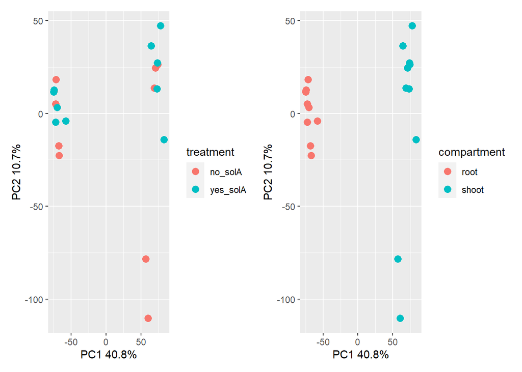

```r
source("Sly1/scripts/create_pca_plot.R")
p1 <- plot_pca(plantpart = c("root", "shoot"), pca_colour = "treatment")
p2 <- plot_pca(plantpart = c("root", "shoot"), pca_colour = "compartment")
p1 + p2
```

On PC1, the compartments cluster together. There is no clear clustering based on solA treatment. Let’s check PC3 and PC4.

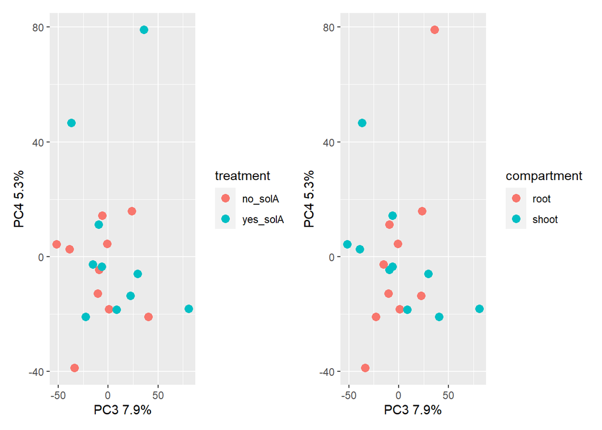

```r
p1 <- plot_pca(plantpart = c("root", "shoot"), pc_x_axis = "PC3", pc_y_axis = "PC4", pca_colour = "treatment")
p2 <- plot_pca(plantpart = c("root", "shoot"), pc_x_axis = "PC3", pc_y_axis = "PC4", pca_colour = "compartment")
p1 + p2
```

Also no good separation. Let’s plot the screeplot:

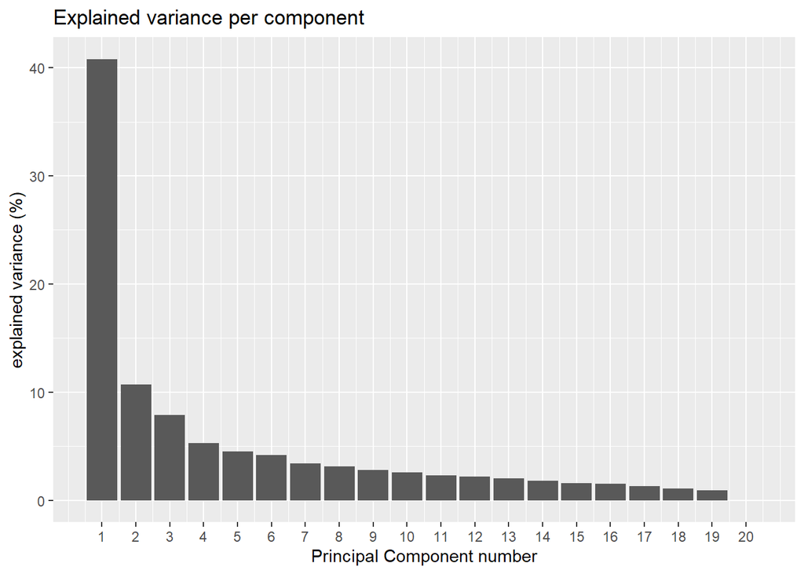

```r
source("Sly1/scripts/scree_plot.R")
plot_scree(comp = c("root","shoot"))
```

It would be more informative to look at the compartments individually.

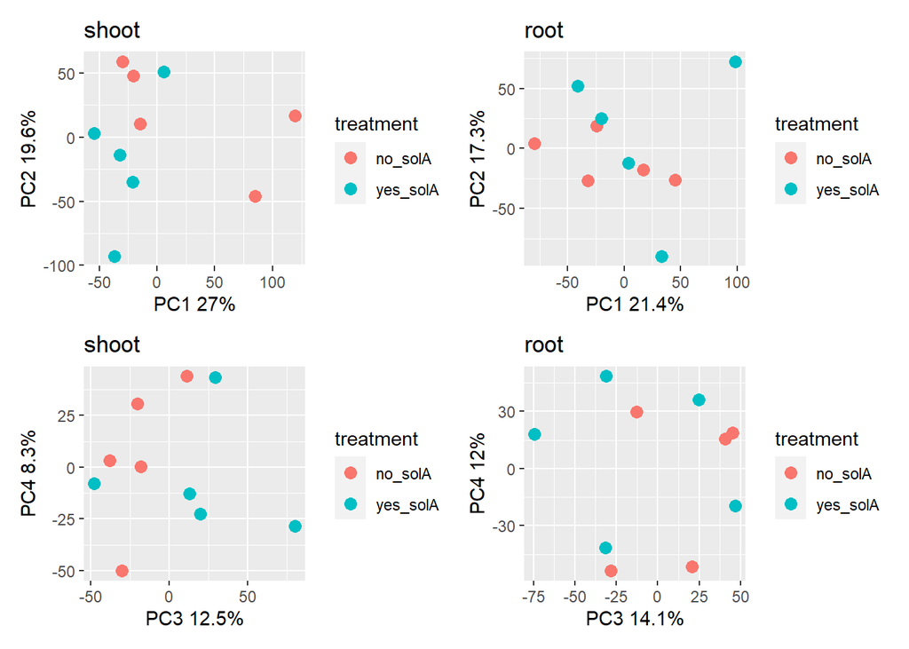

```r
p1 <- plot_pca(plantpart = c("shoot"), pc_x_axis = "PC1", pc_y_axis = "PC2", pca_colour = "treatment") + ggtitle("shoot")
p2 <- plot_pca(plantpart = c("root"), pc_x_axis = "PC1", pc_y_axis = "PC2", pca_colour = "treatment") + ggtitle("root")
p3 <- plot_pca(plantpart = c("shoot"), pc_x_axis = "PC3", pc_y_axis = "PC4", pca_colour = "treatment") +ggtitle("shoot")
p4 <- plot_pca(plantpart = c("root"), pc_x_axis = "PC3", pc_y_axis = "PC4", pca_colour = "treatment") + ggtitle("root")
(p1 + p2) / (p3 + p4)
```

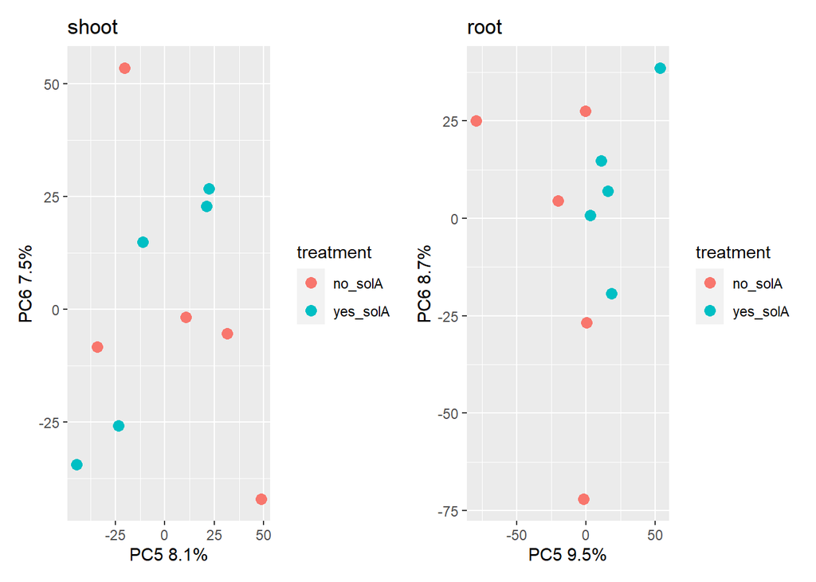

```r
p1 <- plot_pca(plantpart = c("shoot"), pc_x_axis = "PC5", pc_y_axis = "PC6", pca_colour = "treatment") + ggtitle("shoot")
p2 <- plot_pca(plantpart = c("root"), pc_x_axis = "PC5", pc_y_axis = "PC6", pca_colour = "treatment") + ggtitle("root")
p1 + p2
```

In root, there seems to be solA separation in PC5, in shoot, clustering based on solA treatment is difficult to observe. But since the treatment is applied on the roots, this might not be so surprising.

Check the screeplots for separate compartment PCA:

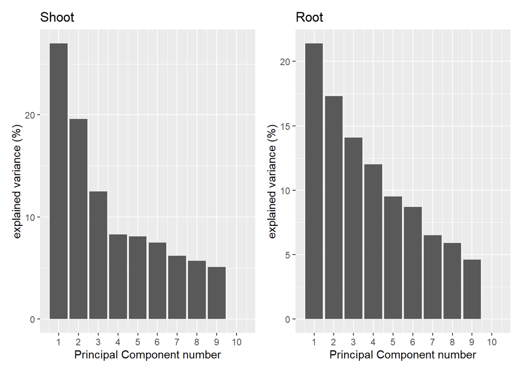

```r
p1 <- plot_scree(comp = "shoot") + ggtitle("Shoot")
p2 <- plot_scree(comp = "root") + ggtitle("Root")
p1 + p2
```

## PLS-DA analysis

We can try to see if supervised clustering analysis gives us better results. We will use PLS-DA and the package mixOmics. First find the optimal number of components with the performance check from mixOmics:

```r
source("Sly1/scripts/perf_plsda.R")
do_plsda_perf(plantpart = c("root","shoot"), n = 99) #this takes some time
```

```
##         max.dist
## overall        2
## BER            2
```

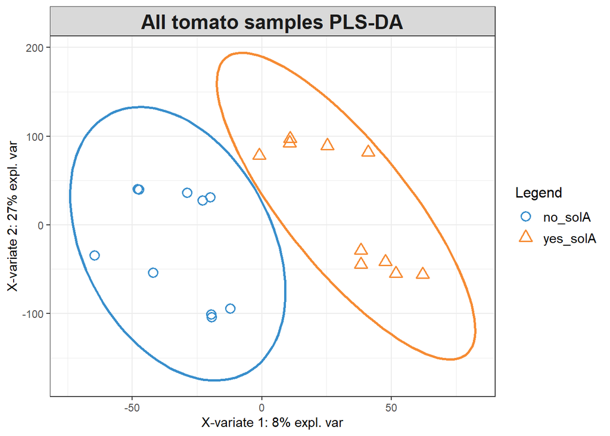

[output not shown]

[output cut: 234 more lines]

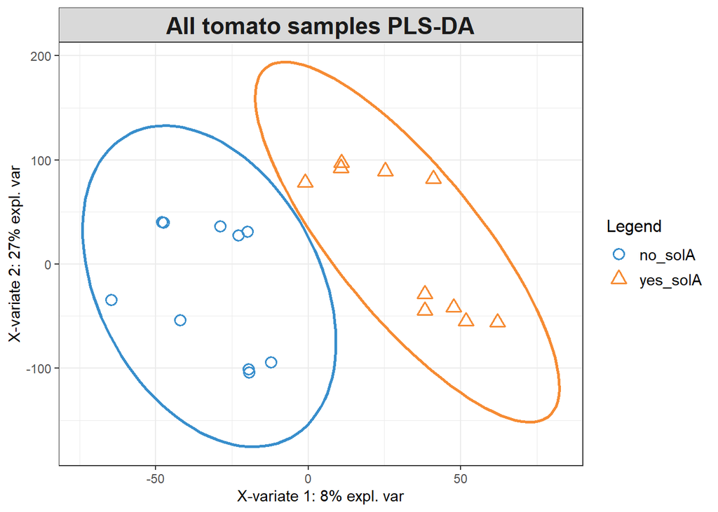

```r
source("Sly1/scripts/plsda.R")
do_plsda(plantpart = c("root","shoot"), nc = 2, ttl = "All tomato samples PLS-DA")
```

This separation is much better.

But within compartments we might find more clear results.

```r
do_plsda_perf(plantpart = "shoot", n = 99)
```

```
##         max.dist
## overall        2
## BER            2
```

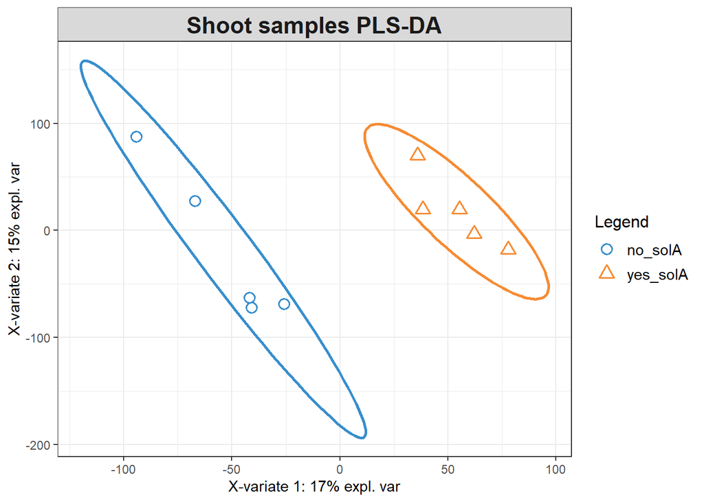

[output not shown]

[output cut: 214 more lines]

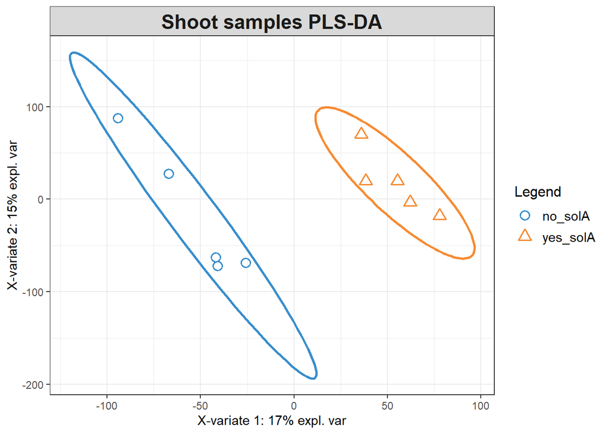

```r
do_plsda(plantpart = "shoot", nc = 2, ttl = "Shoot samples PLS-DA")
```

```r
do_plsda_perf(plantpart = "root", n = 99)
```

```
##         max.dist
## overall        3
## BER            3
```

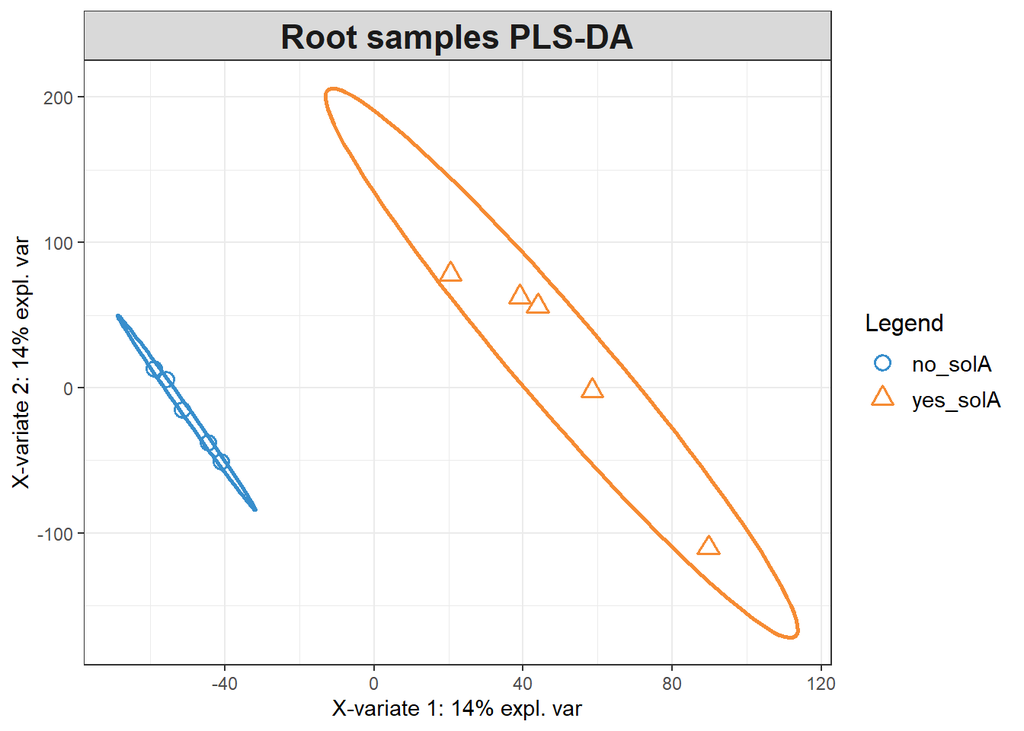

[output not shown]

[output cut: 214 more lines]

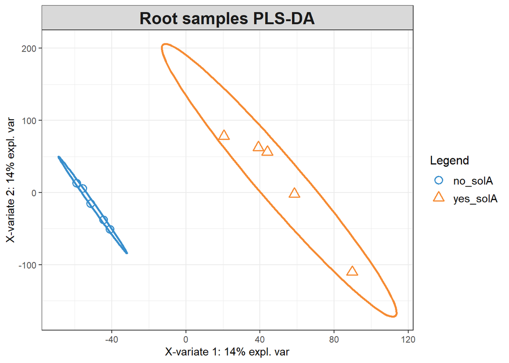

```r
do_plsda(plantpart = "root", nc = 4, ttl = "Root samples PLS-DA")
```

# DEG analysis

## Wald test

Use design formula ~ compartment + treatment

```r
source("Sly1/scripts/volcanoplot.R")
```

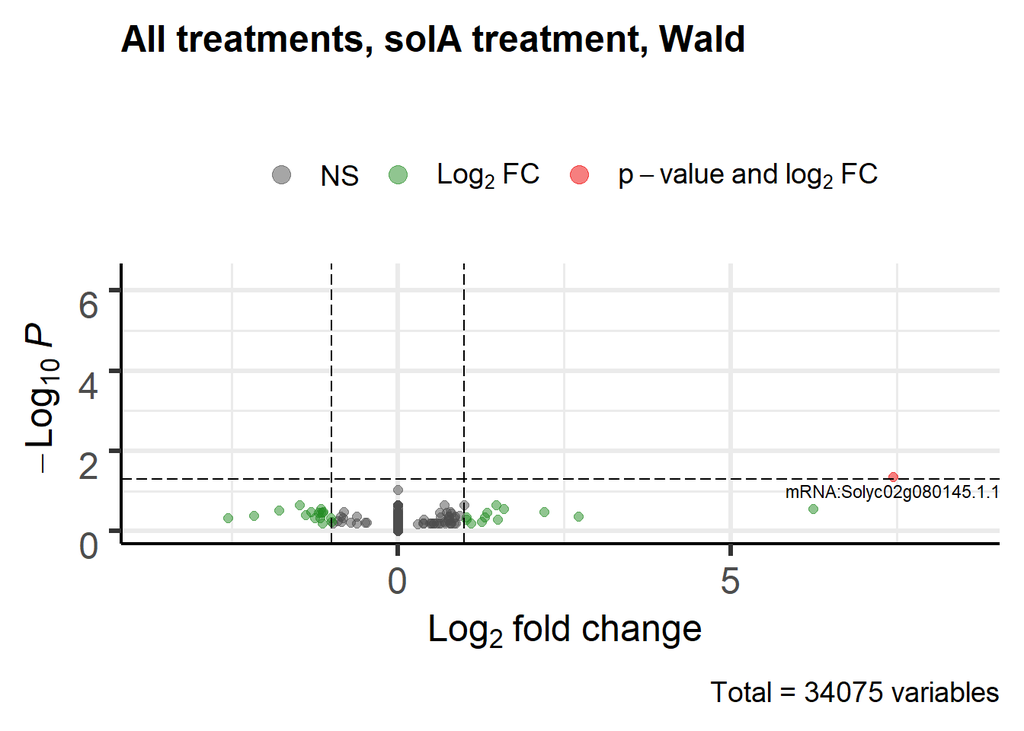

```r
make_volcanoplot(plantpart = c("root","shoot"), log2FC_threshold = 0, FCcutoff_volcano = 1, padj_threshold = 0.05, ttl = "All treatments, solA treatment, Wald", method = "compartment+treatment")
```

There is only 1 DEG.

Again, it makes more sense to look within compartments.

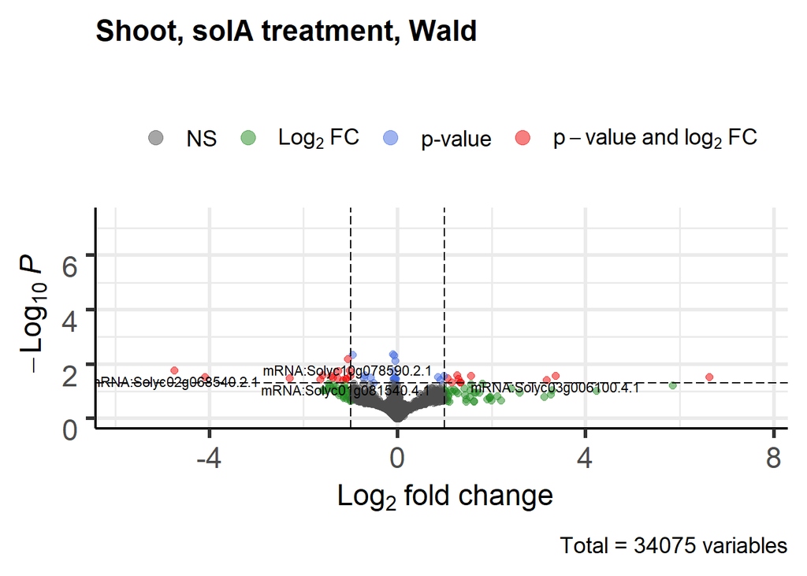

```r
make_volcanoplot(plantpart = c("shoot"), log2FC_threshold = 0, FCcutoff_volcano = 1, padj_threshold = 0.05, ttl = "Shoot, solA treatment, Wald", method = "treatment")
```

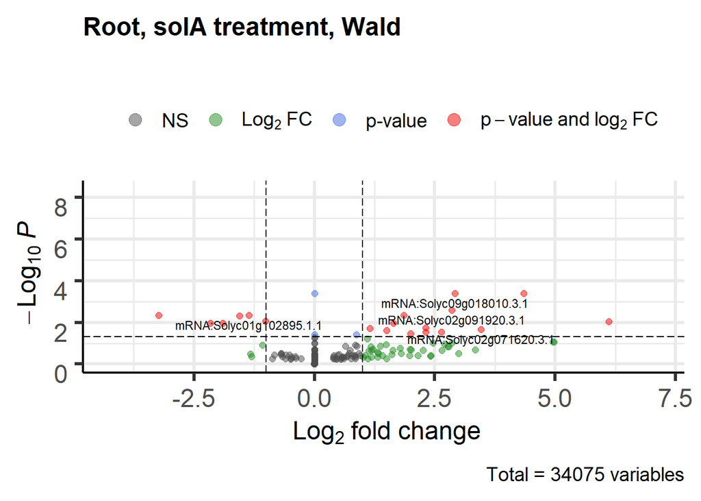

```r
make_volcanoplot(plantpart = c("root"), log2FC_threshold = 0, FCcutoff_volcano = 1, padj_threshold = 0.05, ttl = "Root, solA treatment, Wald", method = "treatment")
```

Indeed, there are several DEGs in both compartments.

## Heatmaps

Since there is only 1 DEG if we take into account all samples at the same time, it is not possible to make a heatmap in that way. Therefore, we only use within compartment DEGs, add those together, and produce a heatmap.

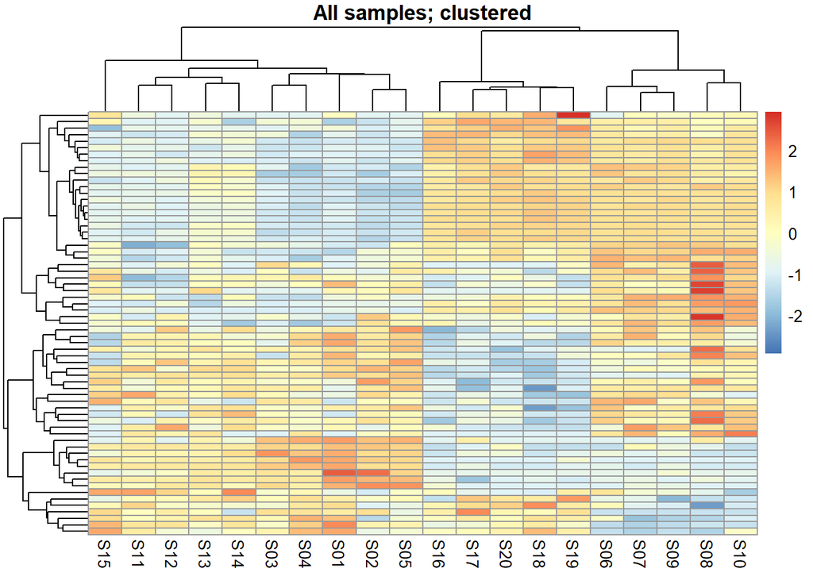

```r
source("Sly1/scripts/get_filtered_list_of_DEGs.R")
xs <- get_list_of_DEGs(plantpart = "shoot", method = "treatment", log2FC_threshold = 0)
xs <- xs %>% rownames_to_column("genes")
xr <- get_list_of_DEGs(plantpart = "root", method = "treatment", log2FC_threshold = 0)
xr <- xr %>% rownames_to_column("genes")
x <- rbind(xs, xr)
source("Sly1/scripts/produce_scaled_counts_matrix.R")
y <- produce_scaled_counts_matrix() %>% column_to_rownames("sample") %>% t() %>% as.data.frame() %>% rownames_to_column("genes")
DEG_counts <- left_join(x, y, by="genes")
DEG_counts <- DEG_counts[, -c(2,3,4,5,6,7)]
DEG_counts <- DEG_counts %>% column_to_rownames("genes")
xp_design <- xp_design %>% column_to_rownames("sample")

pheatmap(DEG_counts,
         gaps_col = c(5,10,15),
         cluster_rows = TRUE,
         cluster_cols = TRUE,
         show_rownames = FALSE,
         show_colnames = TRUE,
         scale = "row",
         main = "All samples; clustered")
```

In this heatmap, samples from the same treatment cluster together, which is good. Also, samples from the same compartment cluster together. There is more differences visible between samples the shoot than between samples of root, which is expected since shoot resulted in more DEGs. Let’s look more into the root samples and see whether they cluster together based on only their DEGs.

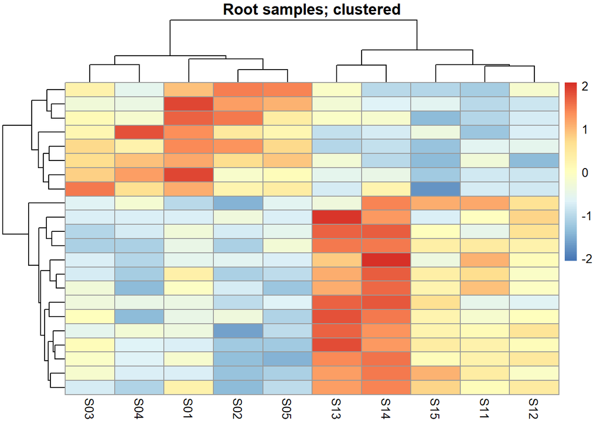

```r
x <- get_list_of_DEGs(plantpart = "root", method = "treatment", log2FC_threshold = 0)
x <- x %>% rownames_to_column("genes")

y <- filter_counts_based_on_compartment(comprtmt = "root") %>% t() %>% as.data.frame() %>% rownames_to_column("genes")
DEG_counts <- left_join(x, y, by="genes")
DEG_counts <- DEG_counts[, -c(2,3,4,5,6,7)]
DEG_counts <- DEG_counts %>% column_to_rownames("genes")
xp_design <- xp_design %>% column_to_rownames("sample")

pheatmap(DEG_counts,
         gaps_col = 5,
         cluster_rows = TRUE,
         cluster_cols = TRUE,
         show_rownames = FALSE,
         show_colnames = TRUE,
         scale = "row",
         main = "Root samples; clustered")
```

Indeed the samples from the same treatment cluster together.

## LRT

Compare Wald test with LRT test, which checks the null-model with the full model. First for the complete tomato dataset.

```r
source("Sly1/scripts/compare_Wald_vs_LRT.R")
compare_wald_vs_LRT(compartment = c("root","shoot"), method = "compartment+treatment")
```

```
## [1] "LRT gives 0 DEGs, while Wald test gives 1 DEGs."
```

```
## # A tibble: 0 x 7
## # ... with 7 variables: gene <chr>, baseMean <dbl>, log2FoldChange <dbl>,
## #   lfcSE <dbl>, stat <dbl>, pvalue <dbl>, padj <dbl>
```

This is a confirmation that there are no overlapping DEGs betwen compartments induced by solA treatment. Check also the within compartment comparisons:

```r
compare_wald_vs_LRT(compartment = "root", method = "treatment")
```

```
## [1] "LRT gives 15 DEGs, while Wald test gives 22 DEGs."
```

```
## # A tibble: 15 x 7
##    gene                 baseMean log2FoldChange lfcSE  stat       pvalue    padj
##    <chr>                   <dbl>          <dbl> <dbl> <dbl>        <dbl>   <dbl>
##  1 mRNA:Solyc01g102890~    158.           -2.09 0.381 -5.47 0.0000000440 4.05e-4
##  2 mRNA:Solyc01g102895~    290.           -1.51 0.312 -4.83 0.00000138   4.54e-3
##  3 mRNA:Solyc02g032660~    114.           -1.13 0.246 -4.60 0.00000424   8.61e-3
##  4 mRNA:Solyc02g091920~     63.0           3.12 0.624  5.00 0.000000562  2.57e-3
##  5 mRNA:Solyc03g034220~   1328.            1.30 0.302  4.32 0.0000156    1.90e-2
##  6 mRNA:Solyc07g016215~   2786.           -1.73 0.364 -4.74 0.00000210   4.79e-3
##  7 mRNA:Solyc07g055740~     13.3           6.63 1.45   4.57 0.00000488   8.92e-3
##  8 mRNA:Solyc08g065670~    105.           -2.44 0.546 -4.47 0.00000765   1.08e-2
##  9 mRNA:Solyc08g078880~     20.9          -3.58 0.749 -4.78 0.00000174   4.54e-3
## 10 mRNA:Solyc09g011080~    146.            1.85 0.411  4.49 0.00000706   1.08e-2
## 11 mRNA:Solyc09g018010~     51.2           3.15 0.582  5.41 0.0000000634 4.05e-4
## 12 mRNA:Solyc09g092720~    156.            2.05 0.428  4.78 0.00000173   4.54e-3
## 13 mRNA:Solyc10g017510~    144.           -2.14 0.478 -4.48 0.00000741   1.08e-2
## 14 mRNA:Solyc10g018300~    103.            1.71 0.404  4.24 0.0000228    2.45e-2
## 15 mRNA:Solyc12g088170~     34.3           4.69 0.868  5.40 0.0000000665 4.05e-4
```

```r
compare_wald_vs_LRT(compartment = "shoot", method = "treatment")
```

```
## [1] "LRT gives 23 DEGs, while Wald test gives 43 DEGs."
```

```
## # A tibble: 23 x 7
##    gene                    baseMean log2FoldChange lfcSE  stat     pvalue   padj
##    <chr>                      <dbl>          <dbl> <dbl> <dbl>      <dbl>  <dbl>
##  1 mRNA:Solyc01g081540.4.1     223.         -1.28  0.321 -4.01 0.0000613  0.0353
##  2 mRNA:Solyc01g074000.3.1     229.          1.44  0.332  4.32 0.0000155  0.0253
##  3 mRNA:Solyc02g065610.3.1     204.         -1.48  0.362 -4.09 0.0000427  0.0327
##  4 mRNA:Solyc02g081190.4.1   35926.         -1.16  0.274 -4.24 0.0000227  0.0273
##  5 mRNA:Solyc03g062720.3.1     232.          1.06  0.268  3.96 0.0000756  0.0389
##  6 mRNA:Solyc03g083400.3.1     929.         -0.821 0.203 -4.05 0.0000515  0.0353
##  7 mRNA:Solyc04g011390.1.1     283.          0.973 0.233  4.17 0.0000308  0.0301
##  8 mRNA:Solyc04g011440.4.1     760.         -1.14  0.251 -4.55 0.00000533 0.0171
##  9 mRNA:Solyc04g014600.3.1     339.         -1.27  0.317 -4.01 0.0000610  0.0353
## 10 mRNA:Solyc04g081530.1.1     223.          1.22  0.298  4.09 0.0000434  0.0327
## # ... with 13 more rows
```

For the root, LRT gives less (15) DEGs than Wald (22), but all of the LRT genes overlap with Wald. For the shoot, LRT gives 23 DEGs and Wald 43, again all of the LRT DEGs overlap with Wald. This is a reasonable confirmation of our DEGs.

# Annotation of DEGs

To infer the function of solA on tomato, we have to infer the function of the DEGs. Since looking at the complete dataset hardly gives us DEGs, we only look at yes/no solA within the compartments.

```r
source("Sly1/scripts/get_annotated_DEGs.R")
DEGroot <- get_annotated_DEGs(plantpart = "root", method = "treatment", name = "Sly1/output/annotated_DEGs_root.csv")
DEGshoot <- get_annotated_DEGs(plantpart = "shoot", method = "treatment", name = "Sly1/output/annotated_DEGs_shoot.csv")
DEGroot$compartment <- rep("root", count(DEGroot))
DEGshoot$compartment <- rep("shoot", count(DEGshoot))
DEGSly <- rbind(DEGroot, DEGshoot)
DEGSly$original_genename <- substr(DEGSly$original_genename, start = 6, stop = 23)
uniquepaste <- function(x) { paste(unique(x), sep = ',', collapse = ",") }
DEGSly <- aggregate(DEGSly, by = list(DEGSly$original_genename, DEGSly$compartment), FUN = uniquepaste)
write_delim(DEGSly, "Sly1/output/allDEGs.csv", delim = ";")
```

Using AgriGO (bioinfo.cau.edu.cn/agriGO/analysis.php), no enriched GO terms are detected for any of the sets of DEGs, neither when taking the DEGs from root and shoot separately nor when combining them.